## —

0. 기본 세팅. tidyverse, data.table, VIM 패키지를 부른 후, setwd로 ‘data.csv’가 있는 폴더로 경로를 설정하고, fread로 ‘data.csv’를 불러오세요.

```r
#install.packages('VIM')

library(tidyverse)
library(data.table)
library(VIM)
#getwd()현재 경로 확인
setwd("C:/Users/user/Desktop/P-SAT/2주차패키지")
data<-read.csv('data.csv')#fread()로 하니 오류가 ㅠㅠㅠㅠ
head(data)
```

```
##     OC bedCount    revenue1 salescost1        sga1     salary1      noi1
## 1 open      175  4217530010          0  3961134739  2033835290  15652441
## 2 open      410          NA         NA          NA          NA        NA
## 3 open      468  1004521989  515483669   447219722   296402310     76156
## 4 open      353 72507342181          0 70677397660 31786048663 506223059
## 5 open      196 49043538016          0 47656051197 24460782270 112352259
## 6 open      243 33580536703 9222996930 23727912054 16655333342  65414325
##         noe1  interest1     ctax1   profit1 liquidAsset1 quickAsset1
## 1   15236236   13236236  31641798 225169678   1012699685   997671878
## 2         NA         NA        NA        NA           NA          NA
## 3      30000          0         0  41864754    272442138   253682170
## 4 1259567512 1196881219 173769780 902830288  13041543085 11534749645
## 5 1419089382 1307248652         0  80749696   6317084032  5873265455
## 6  741269419  336462245         0 -46227375   5635104883  5481680248
##   receivableS1 inventoryAsset1  nonCAsset1   tanAsset1 OnonCAsset1 receivableL1
```

[output cut: 34 more lines]

1. ‘2’로 끝나는 변수를 모두 제거하세요. (단순히 변수의 이름 또는 인덱스 열거를 통한 제거가 아닌 적절한 함수 를 사용할 것) (‘2’로 끝나는 변수는 2016년 기준 값이고, ‘1’은 2017년 기준입니다. 정확한 모델링을 위해서는 이를 모두 고려해야 하지만, 전처리 방법 학습 및 간단한 모델링을 위해 2017년 기준 변수만 사용하도록 하겠습니다.)

```r
data<-data%>% select(!ends_with("2"))
```

2. ‘VIM’ 패키지를 이용하여 다음과 같이 시각화 한 후 간단히 해석해 보세요. (아래처럼 변수가 모두 출력이 안될 수 있습니다. 사용 색: pink, lightyellow)

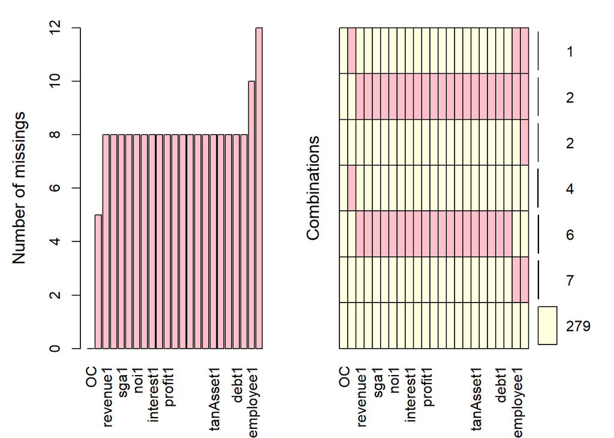

```r
VIM::aggr(data,prop=FALSE,numbers=TRUE,col=c("lightyellow","pink"))
```

3-1 NA imputation. 숫자 데이터의 NA값을 mean imputation을 통해 채우세요. (lapply 이용할 것)

```r
data1<-lapply(data, mean, na.rm = T)
for (i in 2:22){
  data[[i]] <- ifelse (is.na(data[[i]]) , data1[[i]], data[[i]])
}

#for (i in 2:22){
#  print(sum(is.na(data[[i]]))) ### na값이 없음을 알 수 있음
#}
```

3-2. NA imputation. 범주 데이터의 NA값을 mode imputation을 통해 채우세요.

```r
names(which.max(table(data$OC)))           #최빈값: "open"
```

```
## [1] "open"
```

```r
names(which.max(table(data$ownerChange)))  #최빈값: "same"
```

```
## [1] "same"
```

```r
data[[1]] <- ifelse (is.na(data[[1]]) , "open", data[[1]])
data[[23]] <- ifelse (is.na(data[[23]]) , "same", data[[23]])

#for (i in 1:23){
#  print(sum(is.na(data[[i]])))     ### na값이 없음을 알 수 있음
#}
```

4. 변수 ‘OC(병원 개/폐업 여부)’를 타겟 변수로 사용하기 위해 “open”을 1, “close”를 0으로 바꾸세요.

```r
print(unique(data$OC))
```

```
## [1] "open"  "close"
```

```r
data$OC <- ifelse (data$OC=="open" , 1, 0)
print(unique(data$OC))
```

```
## [1] 1 0
```

5. 숫자 데이터 중 integer 자료형인 경우 num(numeric) 자료형으로 바꾸세요. (lapply 이용할 것)

```r
data[,1:22]<-lapply(data[,1:22],as.numeric)
```

Chapter 2. 분류모델

```r
library(caret)
library(MLmetrics)
library(randomForest)
```

1. 앞서 전처리한 데이터를 createDataPartition으로 7:3으로 train과 validation set으로 나누세요. (seed :1234, p: 0.3)

```r
set.seed(1234)
train_idx=createDataPartition(data$OC, p=.3, times=1, list=FALSE)
train=data[-train_idx,]
validation=data[train_idx,]
```

2 Hold-out. train 데이터의 모든 변수를 이용하여 ‘OC’를 타겟으로 하는 로지스틱 회귀를 만들고 validation set의 Accuracy값을 구하세요.

```r
train_x=train %>% select(-OC) %>% as.matrix()
train_y=train %>% select(OC) %>% unlist %>% as.vector
validation_x=validation %>% select(-OC) %>% as.matrix()
validation_y=validation %>% select(OC) %>% unlist %>% as.vector


model_glm = glm(OC ~ . , family="binomial", data = train)
model_glm%>%summary()
```

```
##
## Call:
## glm(formula = OC ~ ., family = "binomial", data = train)
##
## Deviance Residuals:
##      Min        1Q    Median        3Q       Max
## -2.65580   0.00001   0.01373   0.11327   1.39761
##
## Coefficients:
##                   Estimate Std. Error z value Pr(>|z|)
## (Intercept)      2.092e+00  1.209e+00   1.731   0.0835 .
## bedCount        -5.748e-03  1.042e-02  -0.552   0.5812
## revenue1        -7.791e-07  1.151e-05  -0.068   0.9461
## salescost1       7.785e-07  1.151e-05   0.068   0.9461
## sga1             7.814e-07  1.151e-05   0.068   0.9459
## salary1         -1.858e-09  2.556e-09  -0.727   0.4673
## noi1            -7.838e-07  1.151e-05  -0.068   0.9457
## noe1             7.790e-07  1.151e-05   0.068   0.9461
## interest1       -8.830e-09  6.279e-09  -1.406   0.1596
## ctax1            7.806e-07  1.151e-05   0.068   0.9459
## profit1          7.788e-07  1.151e-05   0.068   0.9461
## liquidAsset1     7.908e-08  1.262e-07   0.626   0.5311
## quickAsset1     -8.027e-08  1.263e-07  -0.636   0.5250
## receivableS1    -1.296e-09  7.712e-10  -1.681   0.0928 .
## inventoryAsset1 -9.233e-08  1.295e-07  -0.713   0.4758
## nonCAsset1       2.518e-08  2.445e-08   1.030   0.3031
## tanAsset1       -2.516e-08  2.450e-08  -1.027   0.3046
## OnonCAsset1     -9.350e-09  2.979e-08  -0.314   0.7536
## receivableL1    -2.760e-06  5.623e-05  -0.049   0.9609
## debt1            1.693e-11  3.092e-10   0.055   0.9563
## surplus1         1.087e-10  5.432e-10   0.200   0.8414
## employee1        3.970e-03  1.539e-02   0.258   0.7964
## ownerChangesame  2.216e+00  1.568e+00   1.413   0.1576
## ---
## Signif. codes:  0 '***' 0.001 '**' 0.01 '*' 0.05 '.' 0.1 ' ' 1
##
## (Dispersion parameter for binomial family taken to be 1)
##
##     Null deviance: 74.307  on 209  degrees of freedom
## Residual deviance: 28.953  on 187  degrees of freedom
## AIC: 74.953
##
## Number of Fisher Scoring iterations: 16
```

```r
glm.prob<-predict(model_glm,newdata=validation,type="response")
glm.pred<-rep("0",91)
glm.pred[glm.prob>0.5]="1"

table(glm.pred,validation$OC)
```

```
##
## glm.pred  0  1
##        0  0  2
##        1  6 83
```

```r
accuracy1<-83/(83+2+6)
accuracy1#정확도: 91.20879%
```

```
## [1] 0.9120879
```

```r
#https://m.blog.naver.com/PostView.nhn?blogId=tjdudwo93&logNo=221041154927&proxyReferer=&proxyReferer=https:%2F%2Fwww.google.com%2F
```

3. 3 Feature selection & Hold-out. 변수선택법 중 단계적선택법을 이용하여 변수를 선택하고, 선택된 변수들로 로지스틱 회귀를 만들어 validation set의 Accuracy값을 구하세요.

```r
step(lm(OC ~., train), scope = list(lower ~ 1, upper = ~.), direction = "both")
```

```
## Start:  AIC=-673.87
## OC ~ bedCount + revenue1 + salescost1 + sga1 + salary1 + noi1 +
##     noe1 + interest1 + ctax1 + profit1 + liquidAsset1 + quickAsset1 +
##     receivableS1 + inventoryAsset1 + nonCAsset1 + tanAsset1 +
##     OnonCAsset1 + receivableL1 + debt1 + surplus1 + employee1 +
##     ownerChange
##
##                   Df Sum of Sq    RSS     AIC
## - liquidAsset1     1   0.00000 6.8152 -675.87
## - quickAsset1      1   0.00006 6.8153 -675.87
## - salary1          1   0.00048 6.8157 -675.85
## - tanAsset1        1   0.00214 6.8173 -675.80
## - employee1        1   0.00322 6.8184 -675.77
## - inventoryAsset1  1   0.00598 6.8212 -675.69
## - OnonCAsset1      1   0.00661 6.8218 -675.67
## - bedCount         1   0.01020 6.8254 -675.56
## - nonCAsset1       1   0.01048 6.8257 -675.55
## - debt1            1   0.01192 6.8271 -675.50
## - ctax1            1   0.01440 6.8296 -675.43
## - salescost1       1   0.01709 6.8323 -675.34
## - revenue1         1   0.01716 6.8324 -675.34
## - sga1             1   0.01732 6.8325 -675.34
## - profit1          1   0.01734 6.8325 -675.34
## - noe1             1   0.01922 6.8344 -675.28
## - noi1             1   0.01961 6.8348 -675.27
## - ownerChange      1   0.03684 6.8520 -674.74
## <none>                         6.8152 -673.87
## - surplus1         1   0.07299 6.8882 -673.63
## - interest1        1   0.07571 6.8909 -673.55
## - receivableS1     1   0.34943 7.1646 -665.37
## - receivableL1     1   0.55124 7.3664 -659.54
##
## Step:  AIC=-675.87
## OC ~ bedCount + revenue1 + salescost1 + sga1 + salary1 + noi1 +
##     noe1 + interest1 + ctax1 + profit1 + quickAsset1 + receivableS1 +
##     inventoryAsset1 + nonCAsset1 + tanAsset1 + OnonCAsset1 +
##     receivableL1 + debt1 + surplus1 + employee1 + ownerChange
##
##                   Df Sum of Sq    RSS     AIC
## - salary1          1   0.00048 6.8157 -677.85
```

[output cut: 340 more lines]

```
## + revenue1         1   0.02103 6.9386 -692.10
## + bedCount         1   0.02032 6.9393 -692.08
## + employee1        1   0.01441 6.9452 -691.90
## - inventoryAsset1  1   0.12048 7.0801 -691.86
## + ctax1            1   0.01062 6.9490 -691.79
## + profit1          1   0.00163 6.9580 -691.51
## + salary1          1   0.00089 6.9588 -691.49
## + liquidAsset1     1   0.00050 6.9591 -691.48
## + OnonCAsset1      1   0.00021 6.9594 -691.47
## + tanAsset1        1   0.00010 6.9595 -691.47
## - noe1             1   0.13736 7.0970 -691.36
## - noi1             1   0.14442 7.1041 -691.15
## - quickAsset1      1   0.27421 7.2339 -687.35
## - receivableS1     1   0.40065 7.3603 -683.71
## - receivableL1     1   0.78465 7.7443 -673.03
```

```
##
## Call:
## lm(formula = OC ~ sga1 + noi1 + noe1 + interest1 + quickAsset1 +
##     receivableS1 + inventoryAsset1 + nonCAsset1 + receivableL1 +
##     surplus1, data = train)
##
## Coefficients:
##     (Intercept)             sga1             noi1             noe1
##       9.733e-01        3.208e-12       -6.651e-11        5.454e-11
##       interest1      quickAsset1     receivableS1  inventoryAsset1
##      -1.541e-10       -1.157e-11       -5.247e-11        1.836e-10
##      nonCAsset1     receivableL1         surplus1
##       3.210e-12       -1.232e-08       -8.217e-12
```

```r
#m <- lm(OC ~ .,data=train)
#step(m, direction = "both")
#Call:
#lm(formula = OC ~ sga1 + noi1 + noe1 + interest1 + quickAsset1 +
#    receivableS1 + inventoryAsset1 + nonCAsset1 + receivableL1 +
#    surplus1, data = train)

#Coefficients:
#    (Intercept)             sga1             noi1             noe1        interest1
#      9.733e-01        3.208e-12       -6.651e-11        5.454e-11       -1.541e-10
#    quickAsset1     receivableS1  inventoryAsset1       nonCAsset1     receivableL1
#     -1.157e-11       -5.247e-11        1.836e-10        3.210e-12       -1.232e-08
#       surplus1
#     -8.217e-12
model_glm_feature = glm(OC ~ sga1 + noi1 + noe1 + interest1 + quickAsset1 +
    receivableS1 + inventoryAsset1 + nonCAsset1 + receivableL1 +
    surplus1 , family="binomial", data = train)
glm.prob_f<-predict(model_glm_feature,newdata=validation,type="response")
glm.pred_f<-rep("0",91)
glm.pred_f[glm.prob_f>0.5]="1"

table(glm.pred_f,validation$OC)
```

```
##
## glm.pred_f  0  1
##          0  0  1
##          1  6 84
```

```r
accuracy1_f<-84/(84+1+6)
accuracy1_f#정확도: 92.30769%
```

```
## [1] 0.9230769
```

4. mtry에 대한 그리드서치를 위해 expand.grid를 이용하여 다음과 같은 데이터 프레임을 만드세요. (데이터 프레임 명: acc_rf)

```r
acc_rf <- expand.grid(mtry=c(3, 4, 5),acc=c(NA))
acc_rf
```

```
##   mtry acc
## 1    3  NA
## 2    4  NA
## 3    5  NA
```

5. 로지스틱회귀에서 선택된 변수들로 랜덤포레스트에 대한 5-fold CV 그리드서치를 진행하여 acc_rf의 acc 변수에 해당 Accuracy값을 넣으세요. (ntree 파라미터를 10으로 설정하고, 이중 for문을 이용하여 직접 코드를 짤 것)

```r
set.seed(1230)#계속 달라져서
train[['ownerChange']]<-as.factor(train[['ownerChange']])
cvstat<-numeric(3)
cvstat
```

```
## [1] 0 0 0
```

```r
for (i in 1:3){
  for (j in 1:5){
    funct<-createFolds(train[['OC']], k=5)#리스트
    index<-funct[[j]]
    cv.train=train[-index,]
    cv.test=train[index,]
    rf=randomForest(OC ~ sga1 + noi1 + noe1 + interest1 + quickAsset1 +
    receivableS1 + inventoryAsset1 + nonCAsset1 + receivableL1 +
    surplus1, data=cv.train,
    mtry=acc_rf[i,1],ntree=10)
    prob_rf=predict(rf,cv.test)
    yhat=ifelse(prob_rf>0.5,1,0)
    table(yhat,cv.test$OC)
    cvstat[j]<-sum(yhat == cv.test$OC) / nrow(cv.test)
    acc_rf[i,2]<-cvstat[j]
  }
}
```

[output not shown]

6. acc_rf에서 가장 높은 Accuracy값의 행을 출력하세요.

```r
c=1
for (i in 1:3){
  if (acc_rf$acc[i]<=acc_rf$acc[i+1]){
    return(c<-i+1)
  }
  else {
    return(c<-i)
  }
}
acc_rf[c,]
```

```
##   mtry       acc
## 2    4 0.9761905
```

```r
acc_rf%>%filter(acc==acc_rf[c,2])
```

```
##   mtry       acc
## 1    4 0.9761905
```

```r
rf_info=randomForest(OC ~ sga1 + noi1 + noe1 + interest1 + quickAsset1 +
    receivableS1 + inventoryAsset1 + nonCAsset1 + receivableL1 +
    surplus1, data=cv.train,
    mtry=acc_rf[2,1],ntree=10)
```

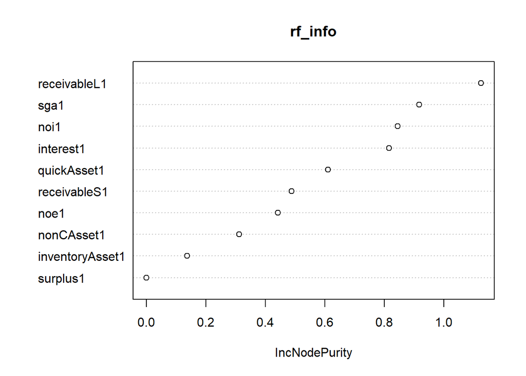

```r
varImpPlot(rf_info)
```

Chapter 3. 회귀모델

```r
#install.packages("MASS")
library(MASS)
```

1. Boston 데이터를 8:2로 train과 test set으로 나누세요. (p: 0.2)

```r
set.seed(1234)

test_idx <- sample(1:nrow(Boston), size=0.2*nrow(Boston), replace=F) # train-set 0.7, test-set 0.3




X_train <- Boston[-test_idx,]

X_test <- Boston[test_idx,]
```

2. expand.grid를 이용하여 다음과 같은 데이터 프레임을 만드세요. (데이터 프레임 명: RMSE_rf)

```r
RMSE_rf <- expand.grid(mtry=c(3, 4, 5),ntree=c(10,100,200),RMSE=c(NA))
RMSE_rf
```

```
##   mtry ntree RMSE
## 1    3    10   NA
## 2    4    10   NA
## 3    5    10   NA
## 4    3   100   NA
## 5    4   100   NA
## 6    5   100   NA
## 7    3   200   NA
## 8    4   200   NA
## 9    5   200   NA
```

3. medv를 종속변수로 하는 랜덤포레스트에 대한 5-fold CV 그리드서치를 진행하여 RMSE_rf의 RMSE 변수에 해당 RMSE값을 넣으세요. (이중 for문을 이용하여 직접 코드를 짤 것)

```r
set.seed(1230)#계속 달라져서
X_train[['medv']]<-factor(X_train[['medv']])

cvstat<-numeric(9)
cvstat
```

```
## [1] 0 0 0 0 0 0 0 0 0
```

```r
for (i in 1:9){
  for (j in 1:5){
    funct1<-createFolds(X_train[['medv']], k=5)#리스트
    index1<-funct1[[j]]
    cv.train=X_train[-index1,]
    cv.test=X_train[index1,]
    rf=randomForest(factor(medv) ~ ., data=cv.train, mtry=RMSE_rf[i,1], ntree=RMSE_rf[i,2])
    prob_rf=predict(rf,cv.test)

    cvstat[j]<-sqrt(mean(sum(as.numeric(cv.test$medv)-as.numeric(prob_rf))))
    RMSE_rf[i,3]<-mean(cvstat[j])##########
  }
}
```

4. RMSE_rf에서 가장 낮은 RMSE값을 가진 행을 출력하세요.

```r
#RMSE이므로 0보다 큼
c=0
for (i in 1:9){
  if (RMSE_rf$RMSE[i]<=RMSE_rf$RMSE[i+1]){
    return(c<-i+1)
  }
  else {
    return(c<-i)
  }
}
RMSE_rf[c,]
```

```
##   mtry ntree    RMSE
## 1    3    10 31.1127
```

5. train set으로 그리드 서치로 나온 가장 좋은 조합의 파라미터의 랜덤포레스트를 학습시킨 후, test set의 RMSE를 구하세요.

```r
rf=randomForest(factor(medv) ~ ., data=cv.train, mtry=3, ntree=10)
prob_rf=predict(rf,cv.test)
sqrt(mean(sum(as.numeric(cv.test$medv)-as.numeric(prob_rf))))
```

```
## [1] 30
```